# eCard Customer Analysis

95791 Data Mining - S21 A3

Group G: Jen Andre (jandre), Tobi Jegede (toj), Callie Lambert (cmlamber)

### Introduction

#### Context and Purpose

Our client is an online greeting card company that charges a subscription fee of $1 per month for unlimited access to their eCard website. The purpose of this report is to advise this client on various aspects of their customer base, including the life-time value (LTV) of their customers.

The LTV of a customer is the total revenue earned by the company from that customer. In the context of this card company, the LTV of a customer is $1 (the monthly subscription fee) times the number of months subscribed.

We aim to address the following primary objectives:

1. Develop an attrition model, to predict whether a customer will cancel their subscription in the near future.
2. Develop a model for estimating the LTV of a customer.
3. Develop a customer segmentation scheme including the identification of sleeping customers (those that are no longer active but have not cancelled their account).

#### Data

The base data set contains four years of daily usage information for 10,000 customers, for the period from 1/1/2011 through 12/31/2014. The fields are as follows:

- `id`: A unique user identifier.
- `status`: Subscription status where 0 = new, 1 = open, and 2 = cancellation event.
- `gender`: User gender where M = male and F = female.
- `date`: Date user logged into the site.
- `pages`: Number of pages visited by user ‘id’ on date ‘date’. This variable is discrete because users can only visit whole numbers of pages.
- `onsite`: Number of minutes user ‘id’ spent on the website on date ‘date’. This variable is continuous.
- `entered`: Flag indicating whether or not user entered the send order path on date ‘date’.
- `completed`: Flag indicating whether or not the user completed the order (sent an eCard) on date ‘date’.
- `holiday`: Flag indicating whether or not at least one completed order included a holiday-themed card on date ‘date’.

#### Report Outline

The structure of this report is as follows:

- Exploratory Data Analysis
- Methodology
- Key Findings and Takeaways
- References

### Exploratory Data Analysis

In this section, we will describe the data and any steps taken to clean or modify the original data set. We will begin by examining summary statistics and checking for missing values. Next, we will present visualizations exploring specific fields and relationships in the daily usage data. Finally, we will describe the creation of a customer-level data set and explore its aggregated fields.

#### Data Set Characteristics

The daily usage data set has 403,835 rows and 9 columns. The data set is clean and has no missing values, so no additional cleaning steps are required.

There are 10,000 unique customers represented in the daily usage data. All 10,000 of these customers begin their subscription with the company within this four-year time period. Of these, 6,317 customers have ended their subscription with the company by the end of this time period. This leaves 3,683 customers whose subscription is still ongoing at the end of 2014. Of the total 10,000 unique customers, 7,924 are female and 2,076 are male.

The median number of pages visited by a user on a given date is 5 and the mean is 5.02. The median minutes spent on the site by a user on a given date is 5 and the mean is 8.83. In total, 78.21% of visits result in a customer entering the send order path, 56.27% of visits result in a customer completing an order, and 22.77% of visits result in a customer completing an order with a holiday-themed card.

#### Summarizing and Exploring Daily Usage Data

In this section, we will display some tables and charts summarizing and exploring the site usage data. These plots demonstrate when customers are most active throughout the year, both in terms of site visits and completed orders.

Each year, there are 3 spikes in the number of visits to the site: February, April through July, and October through December. The spike in the last 3 months of the year is the greatest traffic seen on the site. These months correspond to major American holidays: Valentine’s Day, Easter, Mother’s Day, Father’s Day, Fourth of July, Halloween, Thanksgiving, and Christmas. It’s worth noting that the traffic in March and April is variable depending on the timing of Easter in a given year.

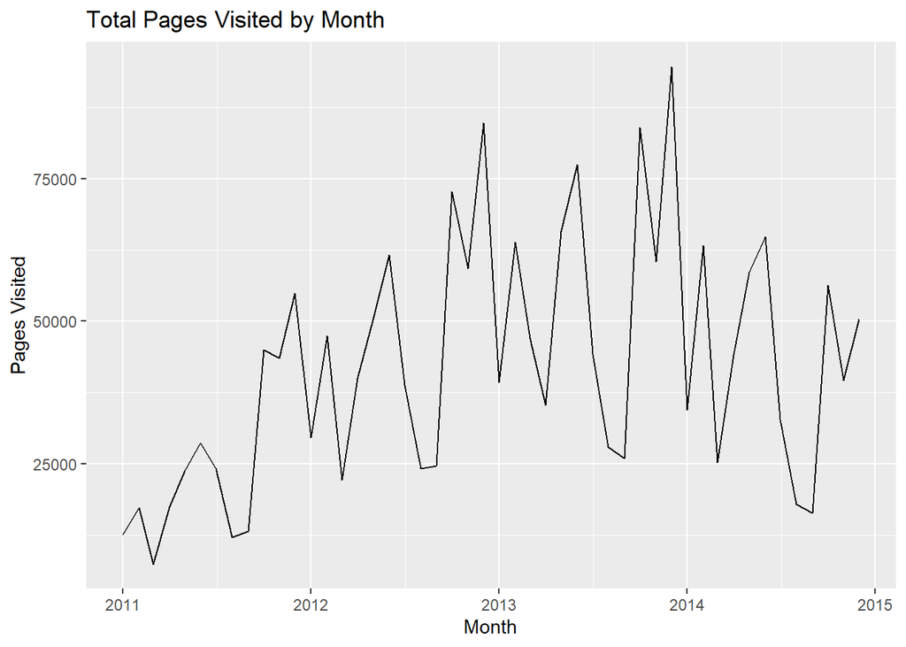

The trend in monthly orders closely aligns with pages visited. As seen in the graph below, the spikes in orders throughout the year are due largely to spikes in the number of orders that included at least one holiday card. The proportion of orders that included at least one holiday card is shown in green on the graph.

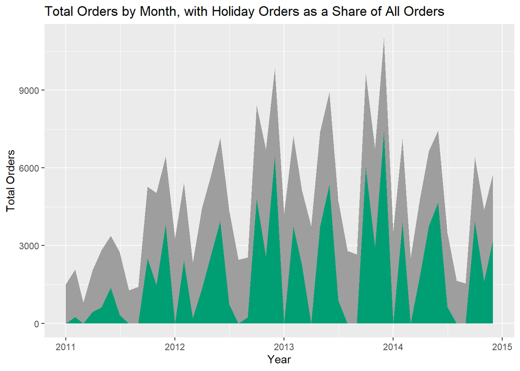

As users visited more pages in their session, the likelihood that they completed an order also increased. As seen in the graph below, approximately 50% of users who visited 5 pages in their session completed an order. In comparison, more than 90% of the users who visited at least 8 pages completed an order in their session. Note that users visiting 0 pages in a visit is a cancellation event.

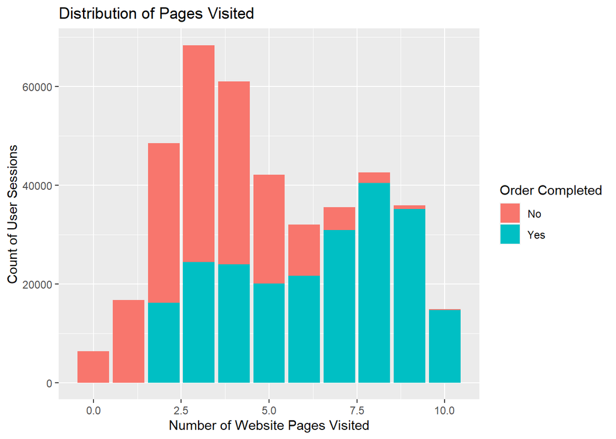

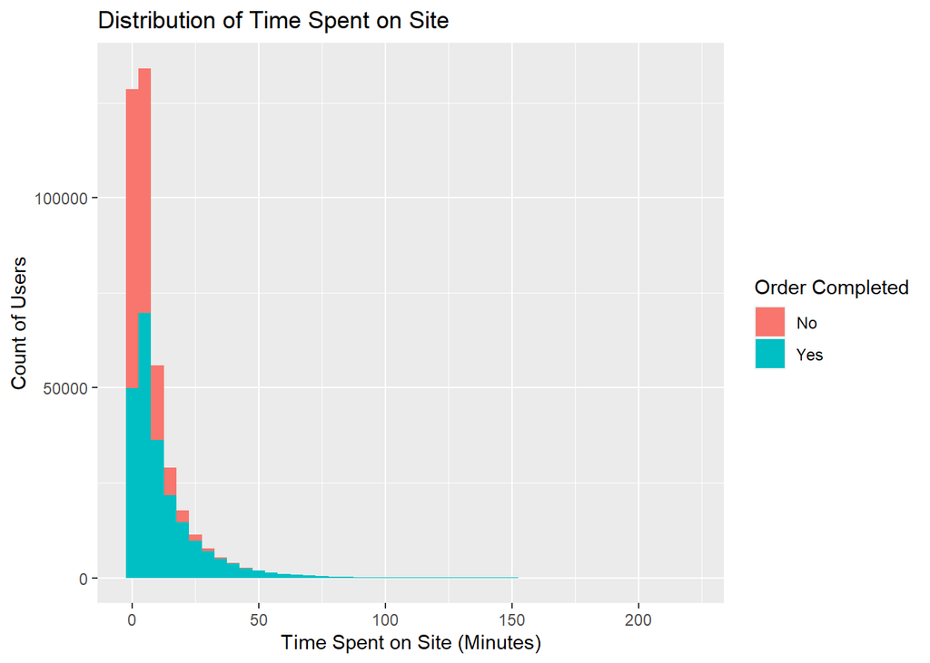

In summary, the exploratory data analysis reveals some interesting trends about usage of the site:

- Website traffic and completed orders spike during holidays.
- As customers visit more pages in a single session, they are more likely to complete an order.
- As customers spend more time on the site, they are more likely to complete an order.

#### The Creation of Customer-Level Data

For some of our analyses, we need data at the customer level rather than daily usage level. We therefore create a data set representing the 10,000 customers. This data set has 18 variables. Fields `id` and `gender` are kept unchanged from the original data set. The other variables are created as follows:

- `cancel`: Flag indicating whether or not the customer has a cancellation event within this time period.
- `avg.num.pages`: Average number of pages visited by customer per day visited.
- `avg.minutes`: Average number of minutes spent by customer per day visited.
- `num.pending.orders`: Number of visits the customer entered the send order path.
- `num.completed`: Number of visits the customer completed an order.
- `num.holiday.cards`: Number of visits the customer ordered a holiday card.
- `num.notcompleted`: Number of visits the customer entered the order path but did not complete an order.
- `num.visits`: Total number of visits.
- `length.sub`: Total number of months of subscription.
- `length.sub.ceiling`: Total months of subscription, rounded up to full months (a user must pay for a full month, even if they cancel early).
- `prop.pending.orders`: Proportion of customer’s visits in which they entered the send order path.
- `prop.completed`: Proportion of customer’s visits in which they completed an order.
- `prop.holiday.cards`: Proportion of customer’s visits in which they ordered a holiday card.
- `prop.notcompleted`: Proportion of customer’s visits in which they entered the order path but did not complete an order.
- `avg.visits.month`: Average number of visits per month.
- `ltv`: Customer life-time value ($1 X `length.sub.ceiling`).

#### Summarizing and Exploring Customer-Level Data

In this section, we will display some tables and charts summarizing and exploring the customer-level data.

##### Subscription Length and Customer Visit Behavior

The average subscription length for all users is 19 months. For users that have cancelled their subscription, the average subscription length was 20 months. On average, active users (those who have not cancelled) have a slightly lower subscription length, with an average of 17 months.

The plots below provide more information about customers’ subscription length (`length.sub.ceiling`). The first shows a peak of users with a subscription length between 10 to 25 months. After 25 months, the number of customers begins to decrease. Note here that the maximum subscription length possible is 48 months given the timeframe of the dataset.

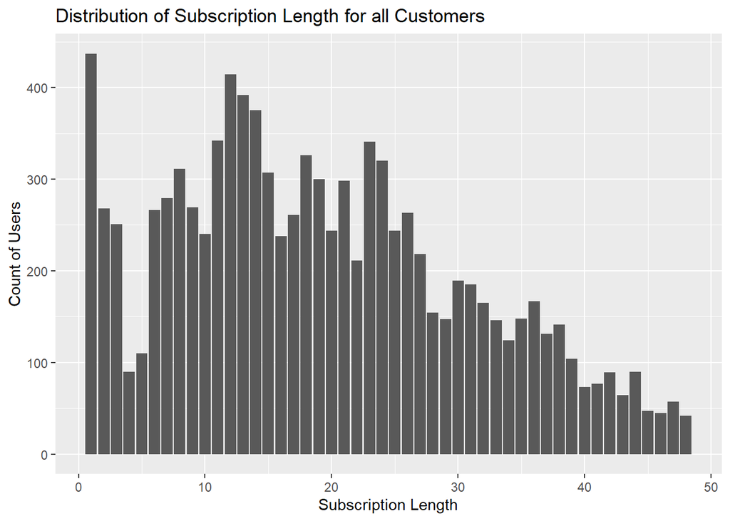

The second plot related to subscription length shows the subscription length along the horizontal axis. The blue bars show the proportion of customers at that subscription length who have cancelled their subscription. We can see that users who have cancelled account for a higher proportion of those with the medium length-subscriptions. This suggests that we should further investigate retention of users with a subscription length between 1-3 years.

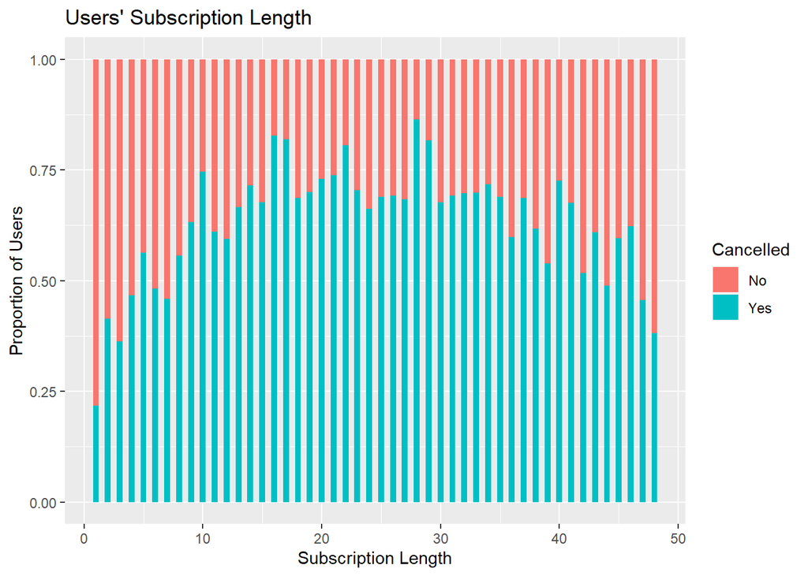

On average, users visited the site 2.42 times per month. Users who haven’t cancelled their subscription tend to visit the site slightly more than users who have cancelled. Active users visited the site an average of 2.98 times per month, while cancelled users visited 2.1 times per month. The boxplot below shows the distribution of the average number of visits for customers, segmented by customers’ cancellation status.

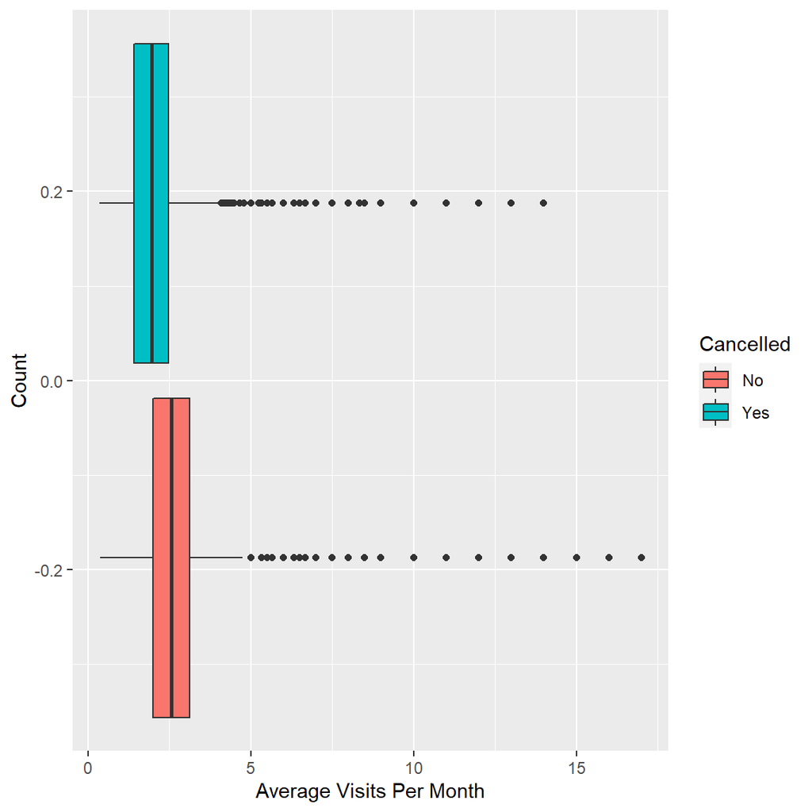

##### Customer Order Behavior

Next, we’ll explore some statistics and charts related to customer order behavior.

The below histogram shows the distribution of `prop.pending.orders`. This field indicates the proportion of visits during which a customer enters the send order path. On average, customers create a pending order on 79% of their visits to the site. The minimum proportion is 0.25, the median is 0.79, and the maximum is 1. A total of 387 customers (4%) enter the send order path on every visit.

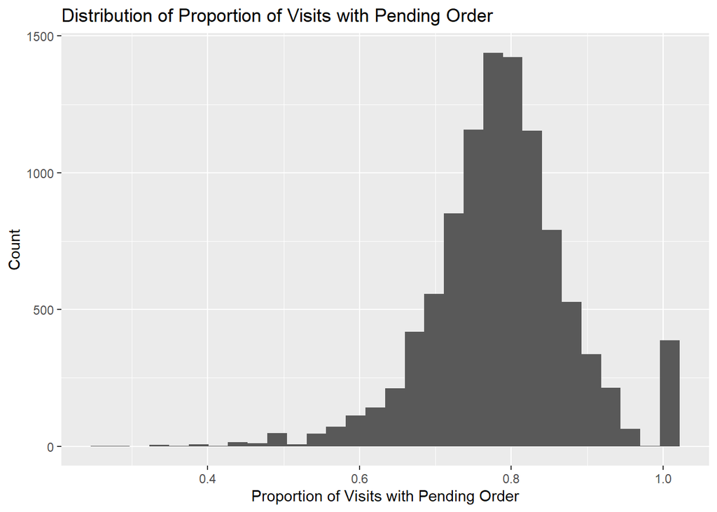

The below histogram shows the distribution of `prop.completed`. This field indicates the proportion of visits during which a customer completes an order. On average, customers complete an order on 59% of their visits to the site. The minimum proportion is 0.15, the median is 0.57, and the maximum is 1. A total of 196 customers (2%) complete an order on every visit.

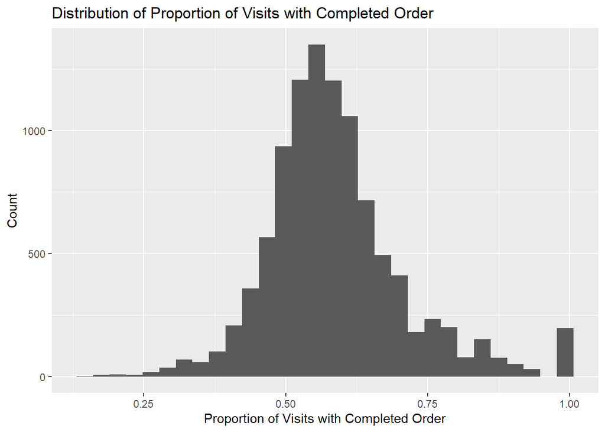

The below histogram shows the distribution of `prop.notcompleted`. This field indicates the proportion of visits during which a customer enters the send order path but does not complete an order. On average, customers fail to complete an order on 20% of their visits to the site. The minimum proportion is 0, the median is 0.21, and the maximum is 0.83. A total of 595 customers (6%) never fail to complete a pending order.

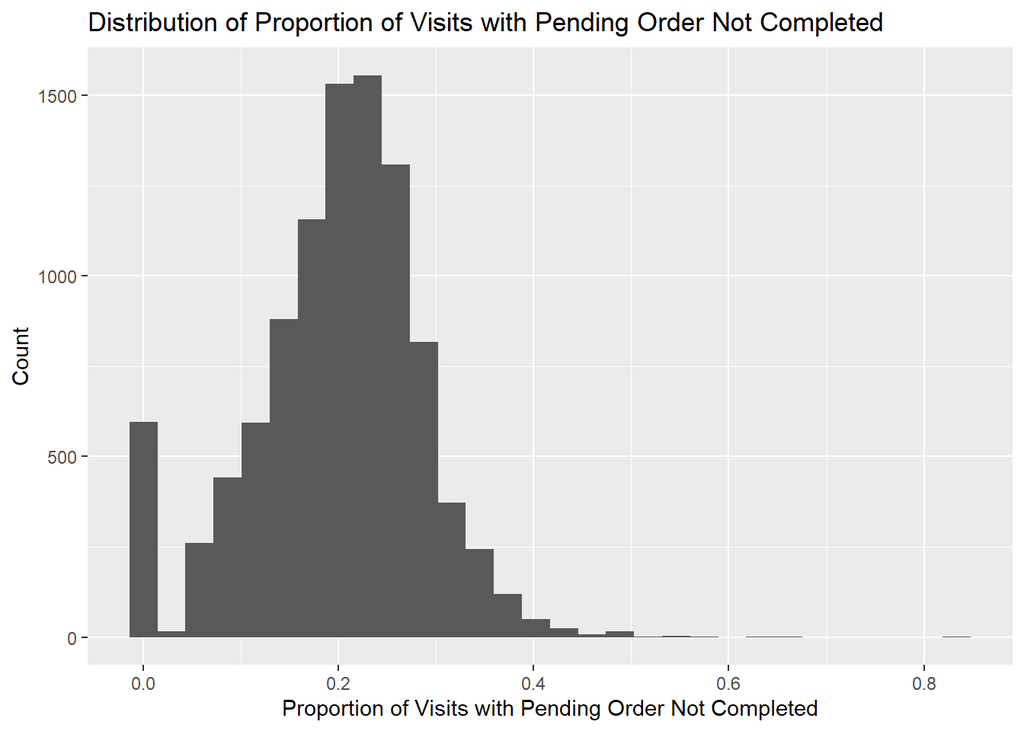

The below histogram shows the distribution of `prop.holiday.cards`. This field indicates the proportion of visits during which a customer orders a holiday card. On average, customers order a holiday card on 21% of their visits to the site. The minimum proportion is 0, the median is 0.22, and the maximum is 0.55. A total of 367 customers (4%) never order a holiday card.

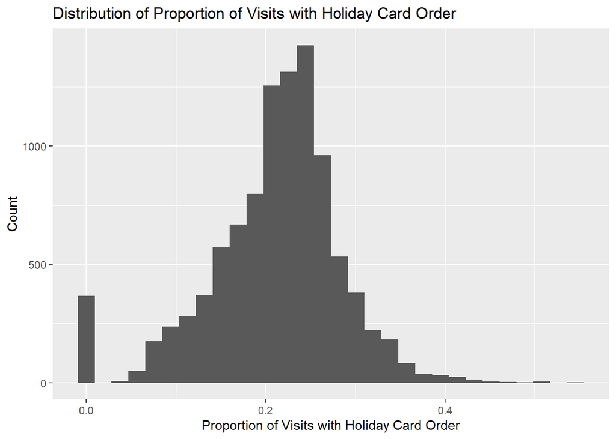

##### Customer Life-Time Value (LTV)

Finally, we will explore some of the relationships between customer life-time value (LTV) and other variables. As noted previously, LTV is calculated as the $1 monthly subscription price times the number of months (rounded up) that a customer is subscribed. A customer must pay for an entire month, even if they cancel early.

The below histogram shows the distribution of customer LTV. This plot includes only customers for which we have a conclusive LTV, i.e. those customers who have started and ended their subscription within the time frame of this data set. The distribution is slightly skewed right. The minimum LTV is $1, the maximum is $48, the median is $19, and the mean is $20.37.

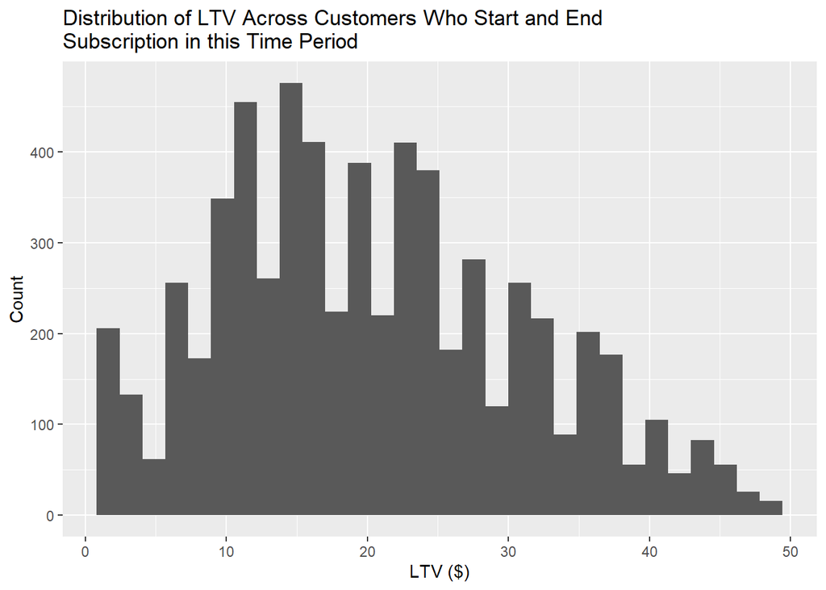

We can also compare the LTV distribution across genders. The below boxplots indicate that LTV values for females are generally larger than for males. A t-test reveals that the average LTV for females ($21.12) is statistically significantly larger than the average LTV for males ($18.03).

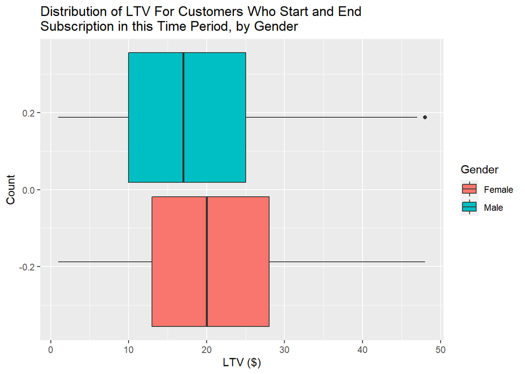

We can also examine the relationships between LTV and other variables.

The scatter plot below shows the relationship between LTV and the proportion of visits in which a customer orders a holiday card. There is an increasing trend. Customers with larger proportions of visits including a holiday card order tend to have higher LTV.

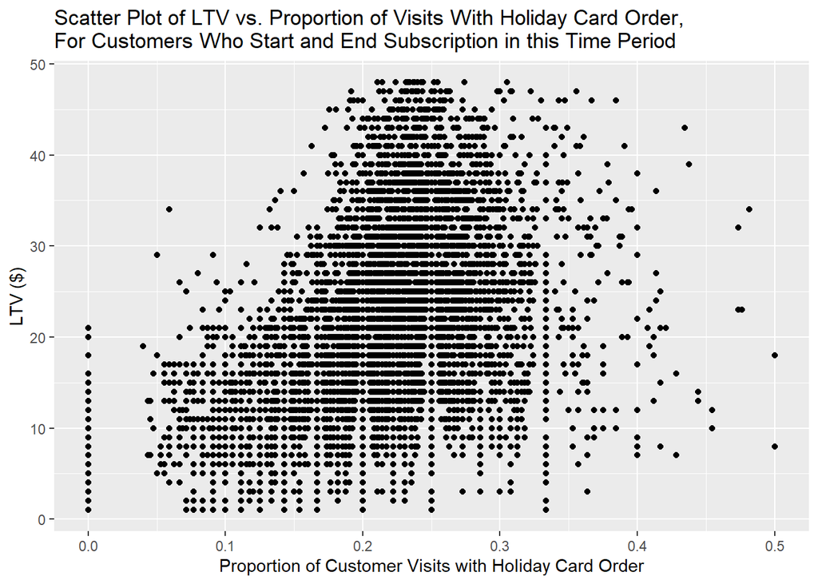

The scatter plot below shows the relationship between LTV and customer-level average site visits per month. For the most part, there is no clear relationship between these variables. Customers with higher LTV generally visit the site the same number of times per month, on average, as customers with lower LTV. However, there is a decreasing relationship at very low levels of LTV. For customers with LTV of approximately $6 or less, LTV decreases as average visits per month increases.

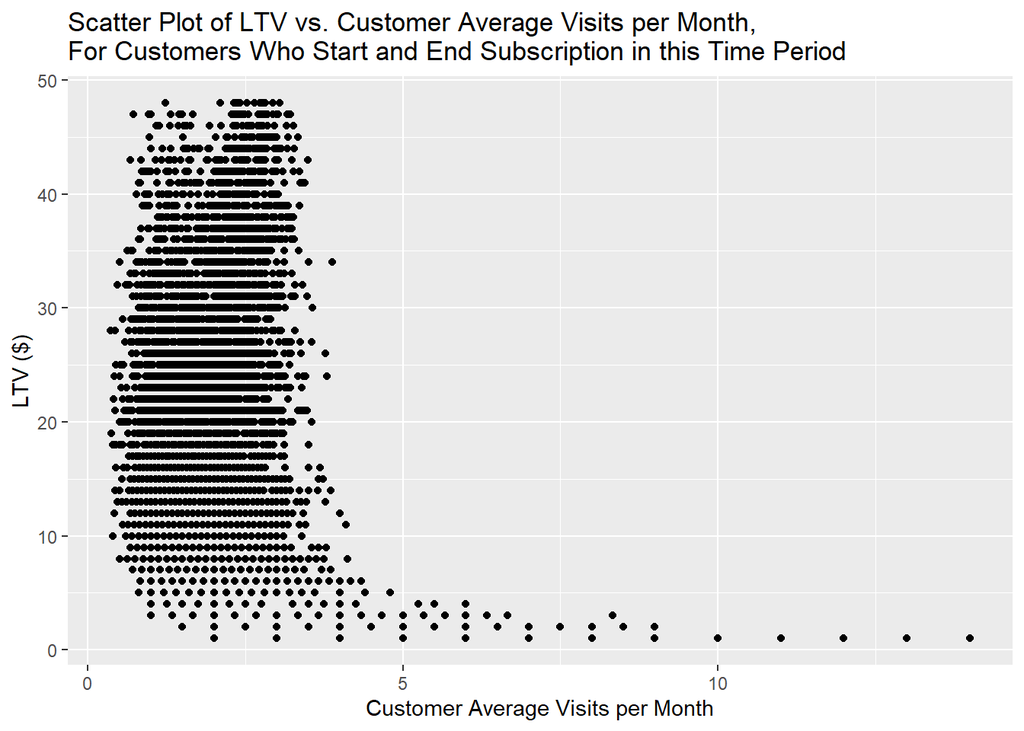

There is a similar relationship between LTV and customer-level average number of pages visited per visit. At higher levels of LTV ($15 or more), there is no clear relationship between these variables, though there does seem to be less variation in average pages as LTV increases. At lower levels of LTV, customer LTV decreases as average number of pages visited increases.

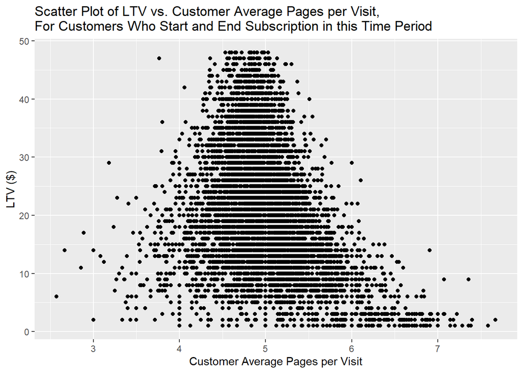

### Methodology

In this section, we will review the data mining methods used to explore our three main objectives and describe the performance of these methods. This review will include descriptions of model selection and model validation processes. Finally, we will describe the final models used in our findings.

#### Methodology: Attrition Model

#### Summary Statistics for Customers with Subscription Cancellations

In order to begin our analysis of customer subscription cancellation behavior, we began by looking at some summary statistics about these customers.

Out of the 10,000 unique customers in the dataset, 6,317 cancelled their subscription from 2011-01-01 to 2014-12-31. This is roughly 63.17% of the population.

For the total population of 10,000, the average subscription length is 19 months or 1.6 years . Of the 6,317 customers who have cancelled their subscriptions, their average subscription length is 20 months or 1.7 years.

After calculating general summary statistics for the customers who cancelled their subscription, we also wanted to explore if there was a temporal dimension that could explain subscription cancellation behavior. To conduct this analysis, we aggregated the data at the month level and found the number of cancellations in each month across the 4 years of data available in the dataset.

Below, we plotted the number of cancellations against the month of the year.

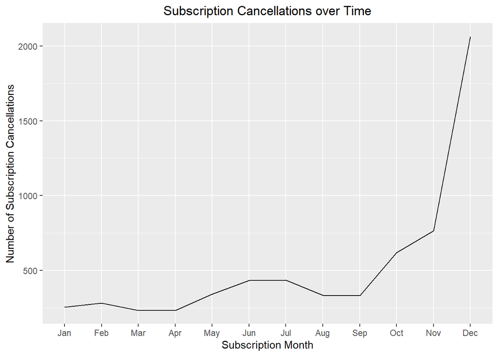

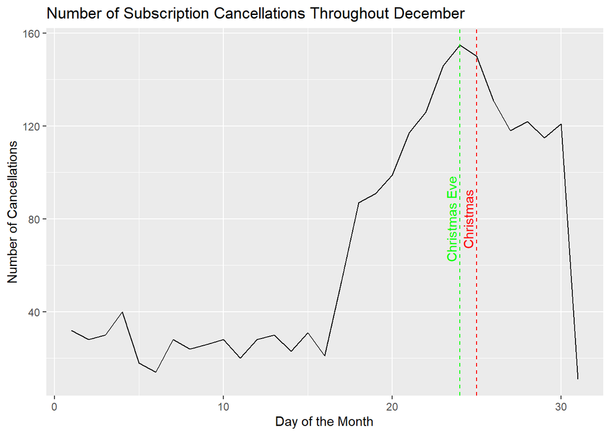

From the plot above, we observed that the highest number of cancellations in December occurred on Christmas Eve.

After finding out general information about the subset of the population who has cancelled their subscription, we then sought to develop an attrition model that would help us to predict whether a customer will cancel their subscription in the near future. We looked at three main lines of analysis:

1. What are the characteristics of customers who cancel their subscription at any point in the four years of data available versus those who do not cancel their subscription?
2. **Of the customers who cancel their subscriptions**, what are the factors that help us predict how long these customers will have their subscriptions?
3. **Using information that we’ve gathered about the smallest length of time it takes someone to cancel their subscription (from the second line of analysis)**, what are the characteristics of customers who will cancel their subscription in the near future?

##### Attrition Model Type #1: Single Decision Tree

To begin the process of predicting customer attrition, we decided to use a classification-based decision tree because our outcome of interest, `cancel`, is a binary variable, where a 1 corresponds to an individual cancelling their subscription (having a status == 2 in the original dataset) and a 0 corresponding to an individual who has not yet cancelled their subscription in the four year period of data available (having status == 0 or status == 1 in the original dataset).

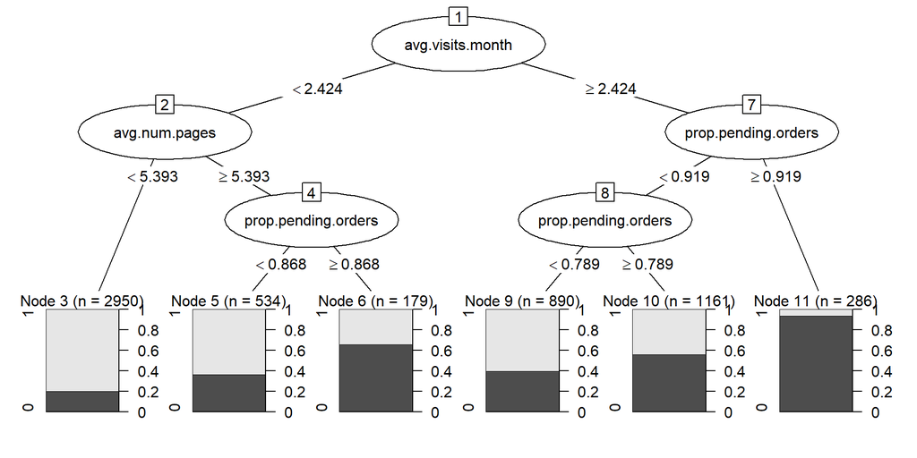

#### Attrition Model: Single Decision Tree Model Evaluation

To begin the process of calculating performance metrics for our single decision tree model, we started off by developing a confusion matrix to map how our observations compared to our predictions, which is captured below.

```
##          observed
## predicted    1    0
##         1 2110  805
##         0  388  697
```

The first line of inquiry for asssesing the performance of the tree-based model for determining whether a customer would cancel their subscription involved looking at the overall accuracy of the model – how many instances of cancellation were predicted as cancellations and how many instances of non-cancellation were predicted to be non-cancellations.

The trained tree has an overall accuracy of approximately 70.17%, meaning that 70.17% of time, the single decision tree model is able to correctly predict that a customer is going to cancel their subscription.

For the purposes of our analysis, in addition to being concerned with overall model accuracy, we would also be more concerned about the presence of false negatives – thinking that someone is not going to cancel their subscription, when they actually do end up cancelling their subscription – than false positives.

The eCard business should be more concerned about false negatives because they would not want to fail to flag a customer who is likely to cancel because there could be interventions they could implement to prevent this behavior. Due to the businesss’ likely focus on reducing false negatives, the focus of our analysis is on reducing the presence of false negatives.

One of the classification performance metrics that is often used when false negatives are more costly than false positives is **sensitivity**. The senstivity for this classification tree is 84.47%. This means that the trained model was able to identify 84.47% of customers who are likely to cancel their subscriptions. The trained model, therefore, appears to do a decent job of detecting attrition behavior. With additional demographic information about customers, the model may be able to pick up more of the true positive instances in the data. The provided dataset currently only includes a “gender” demographic variable and perhaps there are other factors that could assist with our predictive analysis.

In order to see if the sensitivity of the model could be improved, we also tried to used **random forests**. A random forest model would allow us to test out hundreds of potential decision tree models, rather than just single decision tree, and allow us to test out a new set of variables as potential predictors at each split of the data. These characteristics of random forest contribute to its potential to help us better predict which customers would cancel at all during the four year period of data that we have available to us.

#### Attrition Model Type 2: Random Forests

Because there are 13 columns in the subset of the dataset used for this analysis, our choice for the number of randomly selected predictors at each split is 4.

#### Attrition Model: Random Forests Model Evaluation

The senstivity of the model developed through the Random Forest also performed slightly better than the senstivity associated with the model developed by just a singular decision tree model. The practical interpretation of the sensitivity here is that, by using this random forest model, we are able to correctly identify 85.99% of those customers who are going to cancel their subscriptions.

Another feature of random forests is that they enable us to see which variables are the most important in determining the value of the outcome of interest.

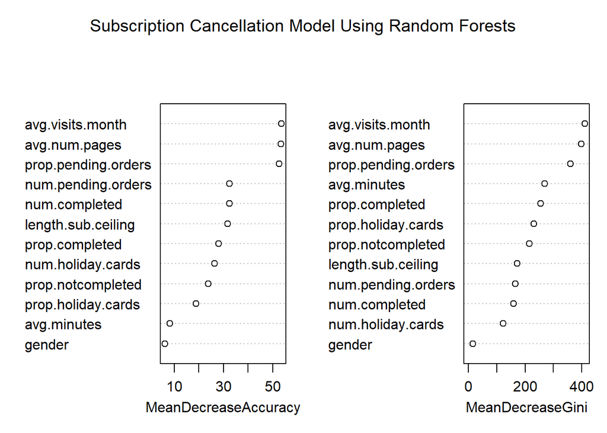

For the purposes of our analysis, we are interested in ensuring node purity, meaning that we are intersted in selecting characteristics that allow us to cleanly segment the customer base into those customers who will cancel their subscription and those who won’t, with limited overlap between the two groups.

In this context, we want the predictors that will best predict the highest number of instances of cancellation. From the `Mean Decrease Gini` plot, the three most important factors in the model that predict whether a customer will cancel their subscription appear to be `avg.visits.month`, `avg.num.pages`, and `prop.pending.orders`.

#### Attrition Model: Predicting Subscription Length for Customers Who Cancelled Subscriptions

In addition to exploring whether or not a customer will cancel their subscription, we also examined how long it took those who cancelled their subscriptions to cancel. In order to assist with this analysis, we created a regression tree because the variable that provides information about subscription length, `length.sub.ceiling` is a continuous variable and therefore the classification tree model used to predict a binary decision of cancelling a subscription or not would not work for this analysis.

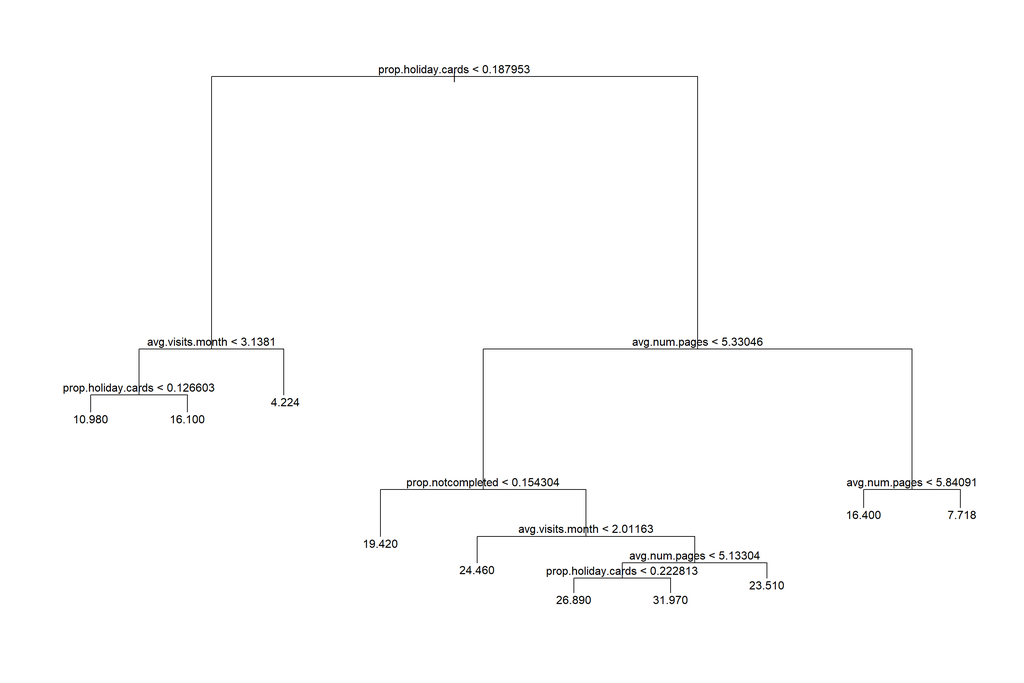

From the tree above, it appears that the factors that seem to best determine the relative length of a customer’s subscription are: prop.holiday.cards, avg.visits.month, avg.num.pages, prop.notcompleted. Particularly, those customers who purchased holiday cards on fewer than 18.7% of their visits to the website and who had more than 3.14 average monthly visits had the shortest subscription lengths, of approximately 4 months.

When we took this tree made from the training data and tried to get predictions for the testing dataset, the mean squared error of the estimates was approximately 61.7%. While the model is fairly accurate in predicting the data, there are likely other factors which we are currently not controlling for that may be better determinants of subscription length for customers who end up cancelling their subscription.

#### Attrition Model: Predicting Cancellation Behavior in the Near Future

We were also interested in determining the characteristics of those who were likely to cancel their subscription in the near future, which we defined as cancelling their subscription within 3 months of beginning their subscription. To conduct this analysis, we used a classification-based decision tree model, given that our predictor was binary.

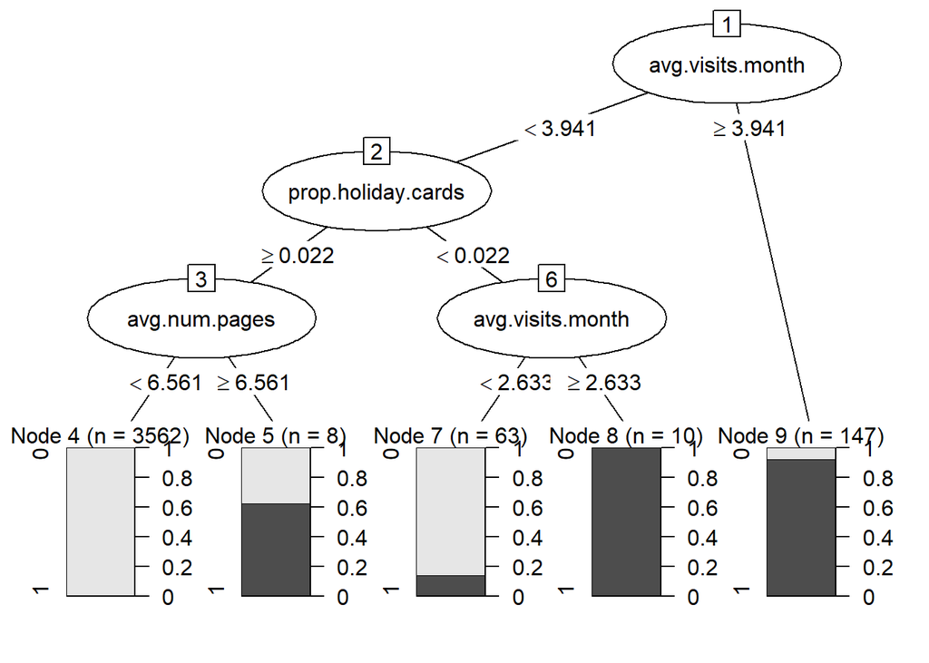

```
##          observed
## predicted    0    1
##         0 2388   19
##         1   22   98
```

#### Methodology: LTV Estimation

##### Introduction and Set-up

Our second objective is to develop a model for estimating the LTV of a customer. To do this, we will explore various data mining prediction modeling techniques and evaluate the performance of each to determine the most useful model for this task.

For this analysis, we will use the customer-level data set restricted to only customers for which we have a completed LTV value. In other words, only customers who have started and ended their subscriptions in this four-year period. Training a model on data that includes customers who have not yet cancelled could result in an under-estimation of LTV, because we do not have a true end point for these customers.

We will exclude some variables from the customer-level data set. First, we will exclude `id`, because it is simply an identifier, and `cancel`, because we have already restricted to just those customers who have ended their subscriptions in this time period (`cancel` = 1). Further, we will exclude the variables that represent total counts, in favor of the variables that measure proportions instead. The excluded variables are: `num.visits`, `num.notcompleted`, `num.holiday.cards`, `num.completed`, and `num.pending.orders`. These are excluded because both they and `ltv` are strongly related to the length of a customer’s subscription, and thus they are not helpful for prediction. Related to this, we also exclude `length.sub` and `length.sub.ceiling`, which is exactly equal to a customer’s LTV. The benefit of the use of proportions and averages in this model, rather than raw counts, is that predictions of LTV can be made after observing just a few months of a customer’s usage behavior.

With this restricted data set, we first explore correlations between the variables. We will want to exclude variables that are highly correlated with other variables to avoid the issue of multicollinearity, which can lead to model estimates that are skewed and difficult to interpret. The correlation plot below shows that no two variables are very highly correlated (correlation coefficient greater than 0.80 or less than -0.80), so no variables are excluded.

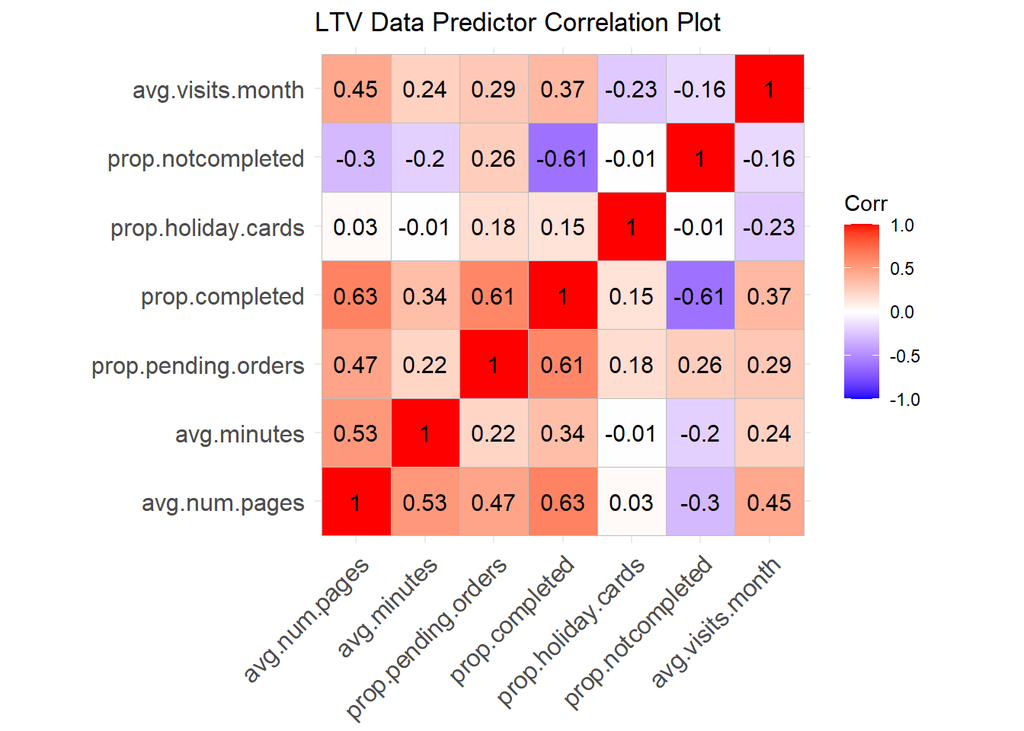

The next step before beginning model exploration is to randomly split the data into training (80% of observations) and testing (20% of observations) data. Models will be fit on the training data, and then we can later evaluate their performance on the unseen testing data. The training data set has 5,054 rows and the testing data set has 1,263 rows.

##### Subset Selection and Linear Regression Model

The first methodology we will explore is using best subset selection to identify the best predictors for a linear regression model.

First, we use best subset selection to determine which variables in the data can best predict a customer’s LTV. Best subset selection works by fitting a linear regression model to every possible combination of predictors in our data. We select the model with the lowest BIC (Bayesian Information Criterion), which is a measure that captures the trade-off between model error and model complexity.

Once we have determined the best set of predictors, we can use a multiple linear regression model to predict LTV. A multiple linear regression model allows us to measure the relationship between LTV and the set of included predictors. This approach models these relationships as linear and fits a regression line that minimizes the squared errors between the predicted and actual LTV values. As we will explore later in this section, we can interpret the coefficients in the resulting model as the impact that each predictor has on LTV, holding all else constant.

The best subset selection process reveals that the best model includes the following predictors: `gender`, `avg.num.pages`, `prop.pending.orders`, `prop.holiday.cards`, and `avg.visits.month`. Next, we fit a linear regression model with these identified predictors on the training data. Using the model printout below, we can interpret the coefficients on each term to explore these relationships.

|  | Estimate | Std. Error | t value | Pr(>\|t\|) |
| --- | --- | --- | --- | --- |
| (Intercept) | 51.5082 | 1.49372 | 34.48 | 0.0000 |
| genderM | -7.9572 | 0.31053 | -25.62 | 0.0000 |
| avg.num.pages | -9.2115 | 0.27800 | -33.13 | 0.0000 |
| prop.pending.orders | 4.3139 | 1.74368 | 2.47 | 0.0134 |
| prop.holiday.cards | 66.8002 | 1.80286 | 37.05 | 0.0000 |
| avg.visits.month | -0.2883 | 0.11759 | -2.45 | 0.0143 |

The interpretations are as follows:

- All else in the model held constant, on average, being male is associated with having $7.96 lower LTV, compared to being female.
- All else in the model held constant, on average, a customer’s average pages per visit increasing by 1 is associated with having $9.21 lower LTV.
- All else in the model held constant, on average, a 10 percentage point increase in the proportion of a customer’s visits in which they enter the send order path is associated with having $0.431 higher LTV.
- All else in the model held constant, on average, a 10 percentage point increase in the proportion of a customer’s visits in which they purchase a holiday card is associated with having $6.68 higher LTV.
- All else in the model held constant, on average, a customer’s average visits per month increasing by 1 is associated with having $0.29 lower LTV.

This estimates are all statistically significant, which means we can be confident that they have not occurred by chance.

Finally, the fitted regression model is used to make predictions with the testing data. For each customer in the testing data set, we get a predicted LTV value. These predicted values can then be compared with the observed values to determine how well the model predicts the LTV values. We will use the mean squared error (MSE), where “error” is the difference between the predicted and observed values.

The linear regression model results in a MSE of 67.27. This suggests that on average, this model predicts LTV values that are on average $8.2 off of the observed values.

##### Lasso Model

The second methodology we will explore is the lasso model. In contrast to the subset selection and linear regression method described above, the lasso method fits a model to all of the available predictors and then “shrinks” the coefficient estimates by minimizing the squared errors subject to a penalty. The estimates on some predictors will become zero, meaning that they are selected out of the model.

The penalty referred to above is tuned using a parameter $\lambda$. This parameter controls the overall complexity of the model, which also determines how well it makes predictions. Below, we will find the value of $\lambda$ that minimizes error by using cross-validation, which is a process the involves repeatedly fitting the model and calculating prediction error at various values of $\lambda$ and with various cuts of the data set. Then, we will also find the value of $\lambda$ that results in cross-validation error that is within one standard error of the minimum cross-validation error. This method (referred to as 1-SE-rule) allows us to select a less complex model, which could have better performance on the unseen testing data.

To use this method, we first fit a lasso model to the training data. Next, we determine the value of $\lambda$ that minimizes CV error and the 1-SE-rule choice of $\lambda$. The plot below shows the increasing relationship between CV error and (log of) $\lambda$.

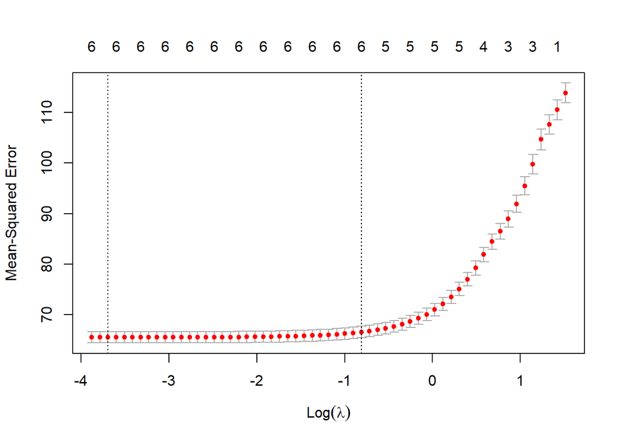

The value of $\lambda$ that minimizes CV error is 0.0248. The value of $\lambda$ that meets the one standard error rule is 0.4444. Next, we use these tuning parameters in the lasso models to predict LTV in the testing data.

We can again use MSE to evaluate the performance of these models. The lasso model with $\lambda$ that minimizes CV error has MSE of 63.37, and the lasso model with $\lambda$ that meets the one standard error rule has MSE of 65.11. These MSE values are lower than the MSE value from the best subset linear regression model, indicating that these models perform better at predicting customer LTV. However, these predictions are still incorrect by $7.96 (using the $\lambda$ that minimizes CV error) and $8.07 (using 1-SE-rule $\lambda$) on average.

##### Regression Tree

The final model we will explore for predicting customer LTV is a regression decision tree. Regression decision trees work by splitting the data using various predictor values, and then averaging the LTV value for the set of data points that end up at the end of each set of branches. Each split is chosen to minimize the squared error between actual and predicted LTV values.

First, we fit a tree model to the training data, and then we can prune it. The pruning process involves cutting back on the tree branches in order to improve prediction performance on the unseen testing data. However, in this case, the un-pruned tree is the best option.

The plot below shows the resulting decision tree. The first split in the data uses the `prop.holiday.cards` variable. Data points with a value of `prop.holiday.cards` < 0.182373 are then split off into the left branch. Then, another split is made on `avg.visits.month` that divides that branch into two nodes. Data points with `prop.holiday.cards` < 0.182373 and `avg.visits.month` < 2.97222 have an average LTV of $14.62. Data points with `prop.holiday.cards` < 0.182373 and `avg.visits.month` >= 2.97222 have an average LTV of $4.77. The other branches and nodes in the below tree can be interpreted similarly.

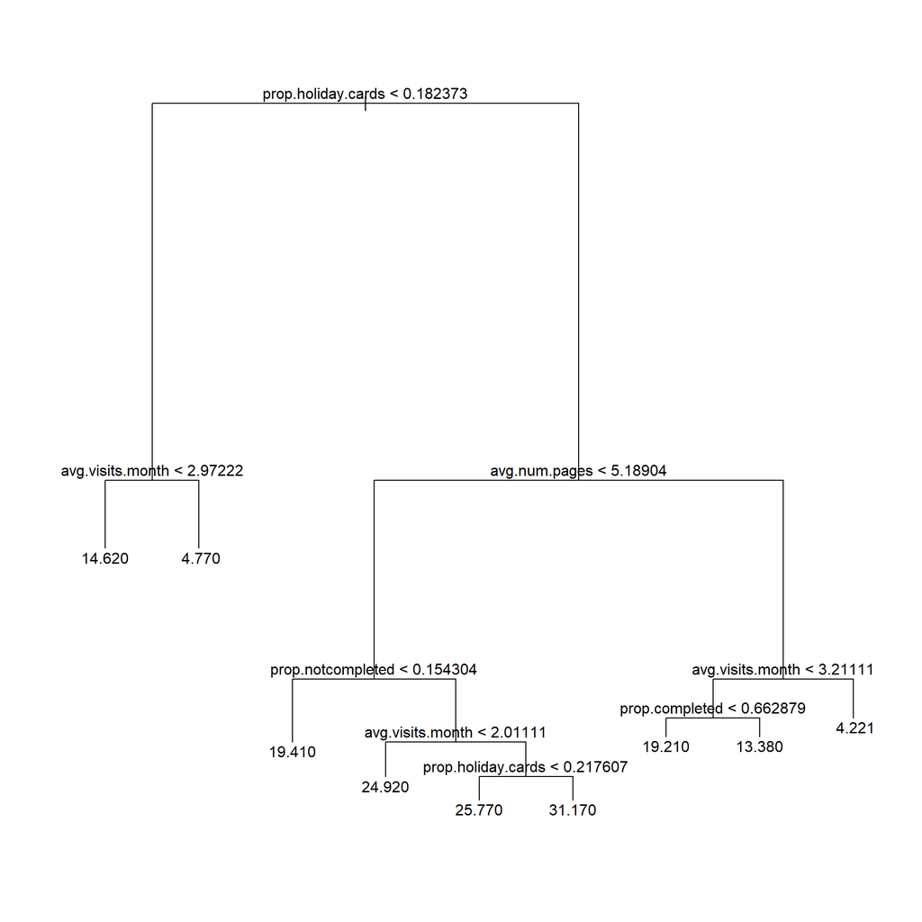

As before, we can use MSE to evaluate the performance of this model on the testing data. The MSE of this model is 63.11, which is lower than all of the previously-explored models. This model is also more easily interpreted than the previous models. We choose this model as our final model for predicting LTV.

#### Methodology: Customer Segmentation

##### Introduction and Set-up

The third objective is to develop a customer segmentation scheme that identifies sleeping, or inactive, customers. These are customers who have not yet cancelled their subscription but are inactive on the site for some period of time. To do this, we will explore various data mining classification techniques and evaluate the performance of each to determine the most useful model for this task.

For this analysis, we will use the observation-level data set, the results of which will be aggregated at the customer level. This analysis relies heavily on the “lag time” for each customer, which is defined as the amount of time (in days) between the customer’s site visits. The lag time is calculated for every observation except a customer’s first event on the site because there is no preceding event. Lag time, in this context, is only relevant for users who have not cancelled, so it is also not calculated for any cancellation events. There is further discussion about lag time throughout the methodology section.

We will exclude some variables from the customer-level data set. First, we will exclude `id`, because it is simply an identifier, and `cancel`, because we have already restricted to active customers. Further, we will exclude the variables that represent total order counts in favor of the variables that measure proportions instead. The excluded variables are: `num.notcompleted`, `num.holiday.cards`, `num.completed`, and `num.pending.orders`. Related to this, we exclude `sleep`, which categories customers as dormant (`sleep` == 1) or not (`sleep` == 0), as this is the predictor variable in the models.

We first explore correlations between the variables. We will want to exclude variables that are highly-correlated with other variables to avoid the issue of multicollinearity, which can lead to model estimates that are skewed and difficult to interpret. The strongest correlations are between `prop.completed` & `avg.num.pages`, `propnotcompleted` & `propcompleted`, and `num.visits` & `length.sub.ceiling`. These variables are not excluded at this stage, but these correlations are factored into modeling decisions for this objective.

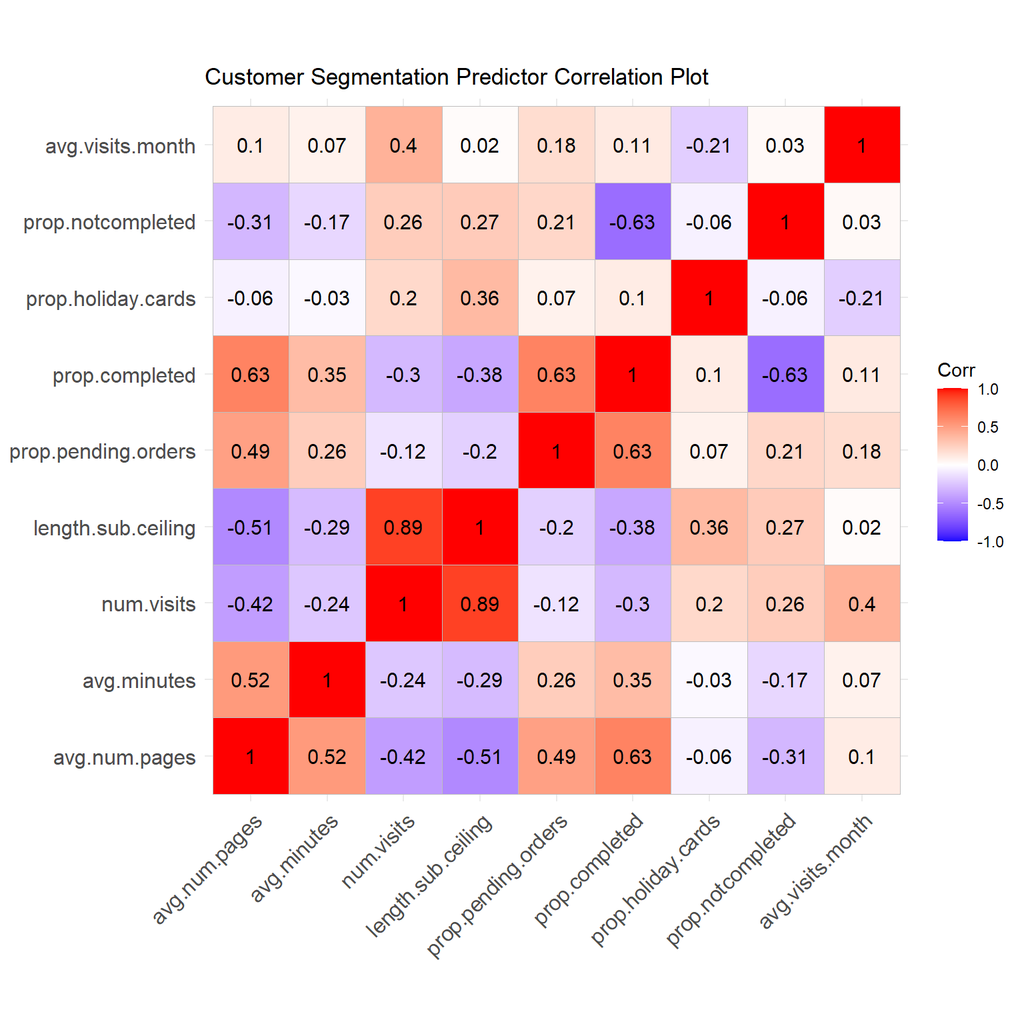

The lag time between each customer’s site visits were calculated and the results were aggregated at the customer level. The customer’s average lag time between visits is `avg.lag` and the maximum amount of time between any two visits is `max.lag`. Although `avg.lag` serves as a useful benchmark for understanding customer behavior, `max.lag` is used to determine whether or not a customer is sleeping. `max.lag` offers insight into whether or not a customer was dormant at any point in their subscription.

The graph below shows the distribution of `max.lag` for all customers. The graph is right-skewed, where most customers have a `max.lag` between 30-90 days.

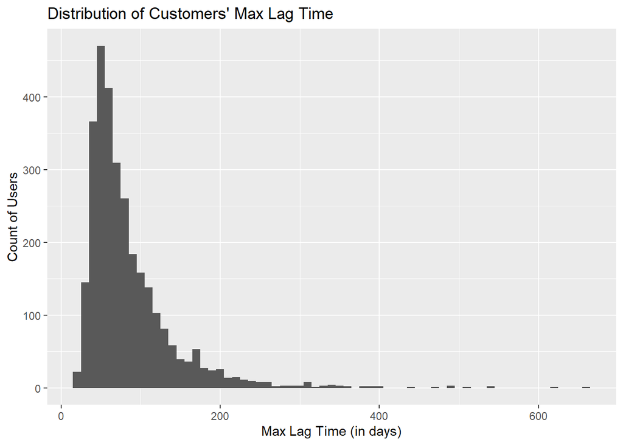

After calculating the `max.lag` for every customer, a cutoff of 90 days was used to determine whether or not a customer is defined at sleeping. The resulting classification is used in model fitting and testing. In other words, if, at any point in their subscription, a customer was inactive for more than 90 days, they are classified as sleeping (`sleep` == 1). This 90-day cutoff was selected for two reasons:

- 90 days is the maximum amount of time between any of the holiday peaks identified in exploratory data analysis. Since we know traffic on the site closely aligns with holiday orders, this 90 day cutoff allows for customers who mostly purchase during the holiday seasons.
- 25% of active customers had a `max.lag` of 102 or more days.

Before we proceed, all customers with a `length.sub.ceiling` less than 3 months were dropped from the dataset used for modeling. Since, by our definition, customers can only be sleeping if they have a `max.lag` greater than 3 months, it is impossible for new users to be “sleeping” and they may skew our results.

As with the previous objectives, the next step before beginning model exploration is to randomly split the data into training (80% of observations) and testing (20% of observations) data. Models will be fit on the training data, and then we can later evaluate their performance on the unseen testing data.

In assessing the models, we calculate the misclassification rate, which is the number of customers in the test dataset that are incorrectly classified as sleeping or not by the model. We also calculate the sensitivity for each model. Sensitivity measures the proportion of customers that were classified as sleeping compared to all of the customers that had an observed status of sleeping. In this scenario, we want to correctly identify those customers that are sleeping even if that means identifying some cases that turn out to be not sleeping.

##### Logistic Regression Models

Logistic regression models the probability for classification tasks with two possible outcomes - it is an extension of the linear regression model. The model provides coefficient estimates that can predict the probability of an outcome (in this case, whether or not a customer is sleeping).

We first fit a logistic regression with the 9 variables available, excluding only those that are highly correlated or directly related to the outcome we are trying to predict. The coefficients on the resulting logistic regression can be interpreted as such:

The following variables are statistically significant in this model: `gender`, `length.sub.ceiling`, `num.visits`, `prop.completed`, `prop.holiday.cards`, and `avg.visits.month`.

Below is a table of the coefficients from the first logistic regression:

|  | Estimate | Std. Error | z value | Pr(>\|z\|) |
| --- | --- | --- | --- | --- |
| (Intercept) | 1.7151 | 0.99769 | 1.72 | 0.0856 |
| gender1 | 1.8315 | 0.23088 | 7.93 | 0.0000 |
| avg.num.pages | 0.0687 | 0.17808 | 0.39 | 0.6999 |
| avg.minutes | 0.0083 | 0.02927 | 0.28 | 0.7757 |
| num.visits | -0.0203 | 0.01029 | -1.97 | 0.0484 |
| length.sub.ceiling | 0.1476 | 0.02494 | 5.92 | 0.0000 |
| prop.pending.orders | 1.5054 | 1.04831 | 1.44 | 0.1510 |
| prop.completed | 2.3058 | 0.95318 | 2.42 | 0.0156 |
| prop.holiday.cards | -8.0096 | 1.13322 | -7.07 | 0.0000 |
| avg.visits.month | -3.4334 | 0.28140 | -12.20 | 0.0000 |

Based on the 9 predictor variables, the model predicts whether or not a customer in the test data is sleeping and we compare those predicted classifications to the true observation for each customer. We then calculate the accuracy of the model by assessing the misclassification rate, which is the number of customers that are incorrectly categorized. The first logistic regression performs fairly well, yielding a misclassification rate of 17.72%. However, this model is perhaps unnecessarily complex and we investigate if we can achieve a similar result with a simpler model.

The simplified logistic regression model predicts `sleep` on 5 predictor variables: gender, the length of the user’s subscription, the user’s average number of visits per month, the proportion of a user’s session that resulted in a completed order, and the proportion of the user’s orders that included holiday cards. These 5 variables were the most significant in the first logistic regression model, which is why they were selected for inclusion in the simplified model. `num.visits` was considered for inclusion but was ultimately omitted given its strong correlation with `length.sub.ceiling`. With fewer variables, the logistic regression model with 5 variables provides a comparable misclassification rate of 18.05% with a slightly higher sensitivity (0.67).

Below is a table of the coefficients from the second logistic regression:

|  | Estimate | Std. Error | z value | Pr(>\|z\|) |
| --- | --- | --- | --- | --- |
| (Intercept) | 3.6177 | 0.48611 | 7.44 | 0 |
| gender1 | 1.9103 | 0.22180 | 8.61 | 0 |
| length.sub.ceiling | 0.0993 | 0.00688 | 14.43 | 0 |
| prop.holiday.cards | -7.3888 | 1.11005 | -6.66 | 0 |
| avg.visits.month | -3.8640 | 0.17532 | -22.04 | 0 |
| prop.completed | 3.1577 | 0.77686 | 4.06 | 0 |

The plot below compares the coefficient values of the two logistic regression models. The predictor variables are listed on the left-hand side and the coefficient estimates are represented as blue circles for the first logistic regression and orange squares for the second, simplified logistic regression. The lines indicate the certainty of the estimate - the shorter the line, the more confidence we can have in that coefficient estimate. The coefficient estimates are fairly consistent across the two models although there are some deviations. There is generally greater certainty about the coefficients in the second model.

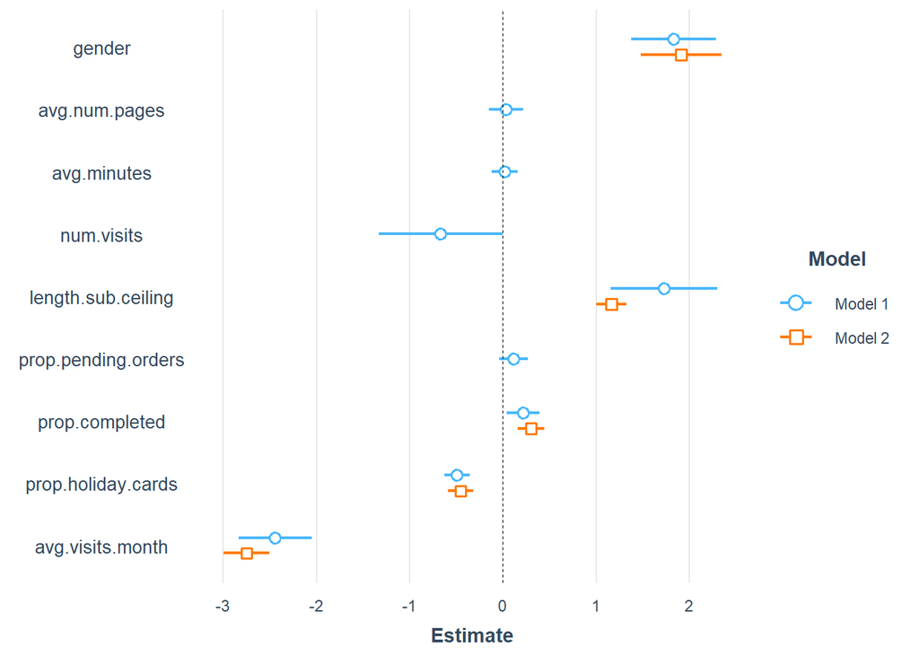

##### Classification Trees

The next category of models that we evaluate are classification tress. Classification decision trees work by splitting the data using various predictor values, and then predicting the outcome (sleeping or not) based on the most common classification at that node.

First, we fit a tree model to the training data, and then we can prune it. The pruning process involves cutting back on the tree branches in order to improve prediction performance on the unseen testing data.

The plot below shows the resulting decision tree. The first split in the data uses the `avg.visits.month` variable. Data points with a value of `avg.visits.month` < 2.32843 are then split off into the left branch. Then, another split is made on `avg.visits.month` that divides that branch into two nodes. Data points with `avg.visits.month` < 2.32843 and `avg.visits.month` < 1.31414 are classified as sleeping. Data points with `avg.visits.month` < 2.32843 but > 1.31414 and a `length.sub.ceiling` > 22.5 are also classified as sleeping. The other branches and nodes in the below tree can be interpreted similarly. All of the nodes split on `length.sub.ceiling` or `avg.visits.month`.

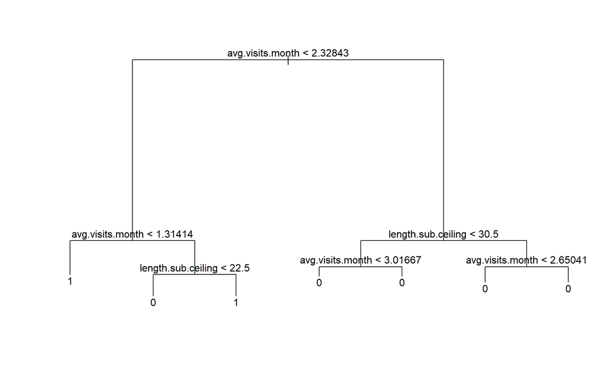

The first decision tree, which is not pruned, grows a relatively accurate tree. This tree has a misclassification rate of 18.38%. However, the sensitivity is only 0.5806452, meaning we’re only identifying 58.06% of sleeping customers. From a business perspective, we would prefer a model that better identifies dormant customers.

Next, we’ll see if we can improve on the original tree by applying pruning and random forest techniques.

The plot below shows the resulting decision tree from pruning. The first split is again on `avg.visits.month`, although this tree has more nodes and branches compared to the first classification tree.

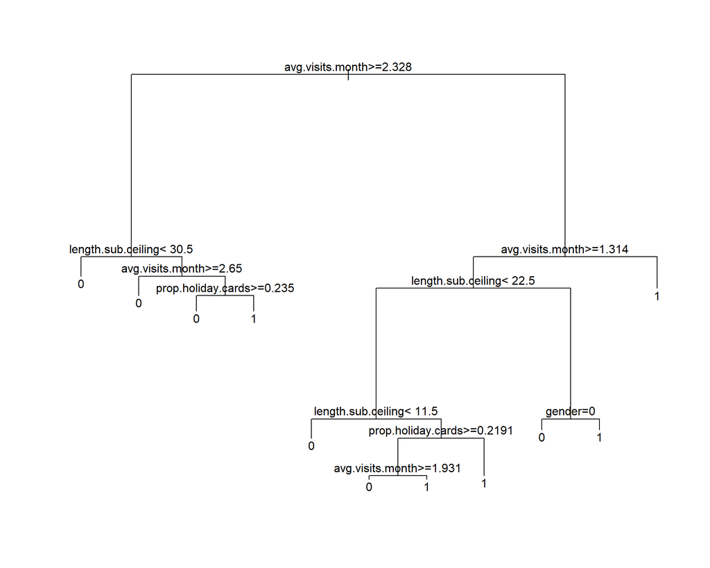

The pruned tree is more difficult to interpret, but it has the highest sensitivity of all models tested thus far (69.35%) while maintaining a consistent accuracy. The nodes in this tree split on `avg.visits.month`, `length.sub.ceiling`, `prop.holiday.cards`, and `gender`.

The last technique we apply is random forest. Random forest decorrelates numerous trees that are generated for the same training data using bagging techniques. At each split in the tree, the tree can only split on a limited set of predictors (and this process repeats for each split on the tree). The results of this model are not interpretable in the same manner as the first two classification trees - in other words, there is no printed tree that cleanly summarizes the random forest technique. Instead we examine some alternate plots that help us understand the random forest results.

The random forest has a similar misclassification rate of 17.05%, but the sensitivity (0.6397849) is in between the other models tested for this objective.

The random forest produces a variable importance plot which helps us understand which predictors have the biggest effect on the model’s fit. The variable importance plot is shown below. The left-hand side of the plot indicates each predictor’s impact on the model’s accuracy and the right-hand side indicates which variables increase node purity. The results of the two plots are similar: `avg.visits.month` and `length.sub.ceiling` are the two most impactful variables on both measures, meaning they have the greatest effect on the model.

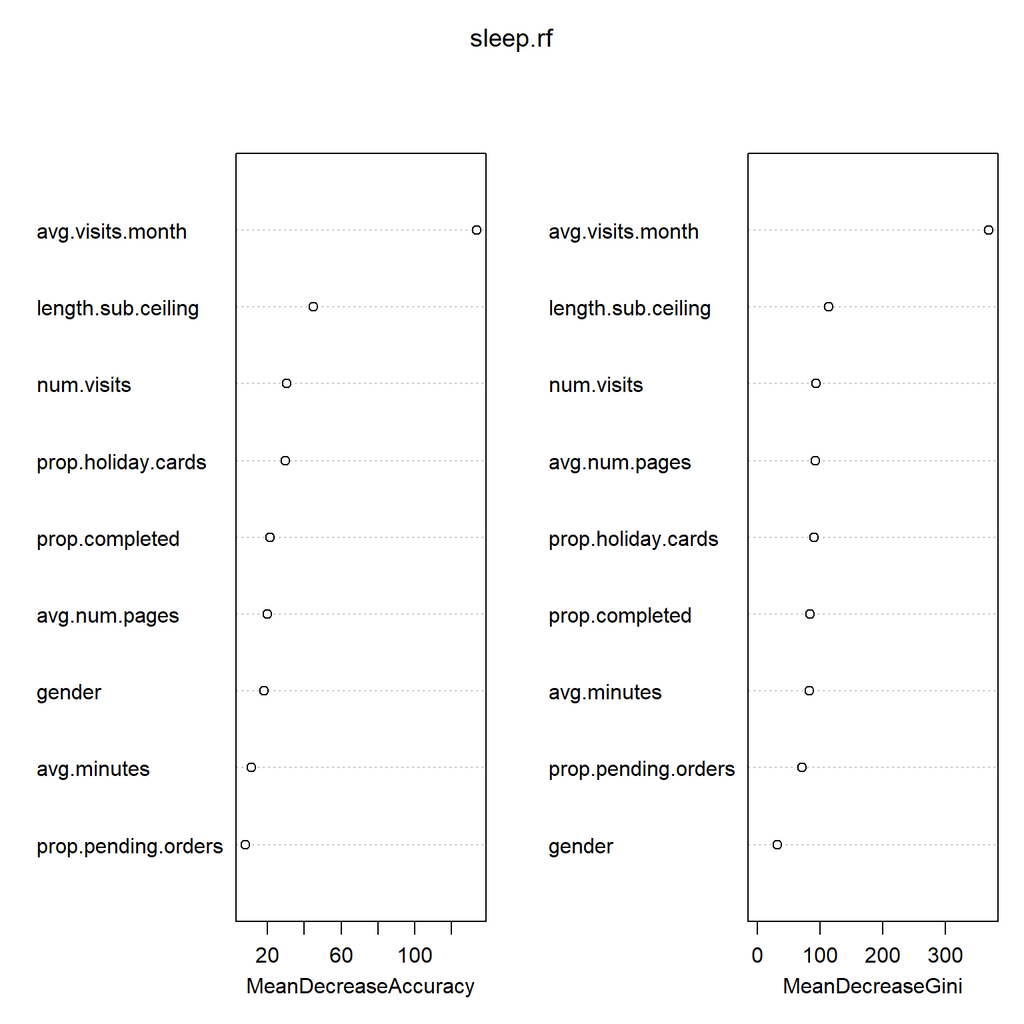

The ROC curve below plots the true positive and false positive rates for the pruned tree and the random forest models. The best classifier would be vertical until it reaches specificity = 1 and then horizontal. We can see that the random forest (plotted in black) and the pruned tree (plotted in blue) are very similar.

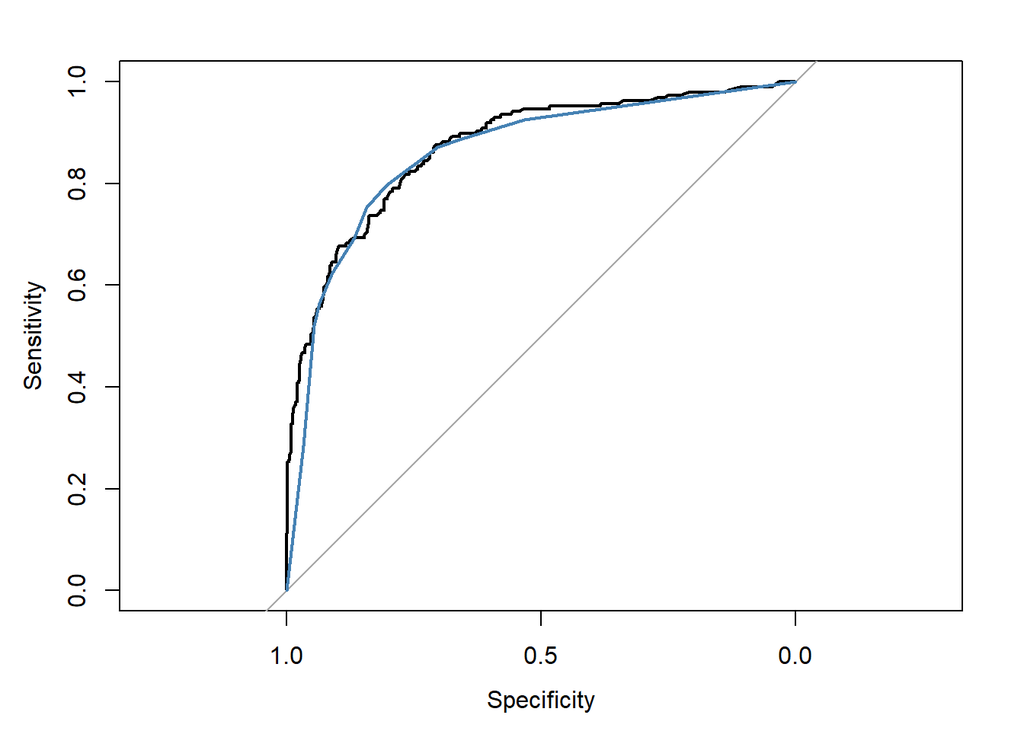

ROC curves produce another useful metric, the area under the curve (AUC). The AUC provides a measure of the general usefulness of the test, where a higher AUC is equated with more usefulness. Again, the random forest and pruned tree perform similarly. The pruned tree has an AUC of 0.86 and the random forest has an AUC of 0.87.

##### Model Selection

The table below compares the misclassification rate and sensitivity for each of the five models considered in this section:

[output not shown]

For the customer segmentation objective, specifically identifying sleeping customers, the model of choice is the simplified logistic regression model with 5 predictor variables. The pruned tree had the highest sensitivity, but the resulting model is difficult to interpret and less applicable to business decisions. Similarly, the random forest is difficult to interpret, although the results are very helpful in determining the predictors that have the greatest impact on classifying customers as sleeping or not. The first decision tree (which was fit without pruning) was easier to interpret, but decision trees are highly variable. This means that the results can change drastically with minor changes to the training data.

### Key Findings and Takeaways

In this section, we will discuss our main findings. We will address our three main objectives, and discuss the strengths and weaknesses of our models and results.

#### Findings: Attrition Model

##### Main Findings

When determining attrition, we explored three dimensions:

1. Whether or not any customer had cancelled their subscription.
2. **For those customers who have cancelled their subscription**, what determines how long they will keep their subscription.
3. **For those customers who have cancelled their subscription**, what factors determine if they cancel their subscription in the near future, which we defined as cancelling their subscription in 3 months.

As discussed above in the methodology section, the best-performing model to predict customer attrition behavior was the random forest model, with an accuracy of 0.709. The three best predictors of attrition behavior based on the random forest model appear to be: `avg.visits.month`, `avg.num.pages`, and `prop.pending.orders`.

The predictors that seemed to best predict whether or not a customer would cancel their subscription in the near future were the `avg.visits.month`, `prop.holiday.cards` and `avg.num.pages`.

A consistent theme among the models is the impact of holiday card purchases on subscription behavior. From our exploratory data analysis, it was clear that subscription cancellation behavior appeared to fluctuate significantly through the year – with the largest spike in cancellations occuring during the December Christmas holiday season. For the eCard business owners, the results of our findings seem to suggest that customer retention programs should be implemented around the holiday season.

##### Implications and Limitations

From a business perspective, in order to ensure that customers will not cancel their subscription, incentives would need to be created, whether through sales or promotions, to increase the number of average monthly visits and average number of pages visited to the eCard store to assist with customer retention. Furthermore, the business could also look for ways to entice customers with pending items in their shopping carts to actually enter a send order path and complete an order.

To ensure longer periods of subscription, the eCard business could also explore providing discounts or promotions around the holiday season, as those customers who purchased more holiday cards appeared to be enticed to hold onto their subscriptions for longer periods of time than their counterparts who purchased few holiday cards.

One of the weaknesses of the analysis is the lack of demographic information available for analysis. There could be additional factors, such as income, that may be able to explain customer subscription behavior. Having this additional demographic variable could’ve helped to determine if there were customers who may have wanted to purchase more cards but were restricted in buying more cards due to fairly limited income. For future analysis of customer attrition behavior, it could be useful to have this information to produce results with even higher degrees of accuracy and sensitivty than the current models.